# Exam 2

Westley Cook

3/27/2020

## Question 1: Wrangling Ecdat

### 1A)

**23.62** percent of men in the sample are married to women who are neither covered by their husband’s insurance nor have health insurance from their own work.

### 1B)

The upper bound of a 90% confidence interval for the mean income of married black men is **21,488** and the lower bound of this interval is **19,753**.

### 1C)

**Bayesian Interpretation** (statement about *probability*):

We can be 90% confident that the true mean income of married black men in the United States falls between the upper and lower bounds of this interval; in other words, there is a 90% chance that the interval captures the true population mean.

**Frequentist Interpretation** (statement about *the process of creating the interval*):

90% of the time we create an interval using the bootstrap method we used here, the interval will contain the true mean income of married black men in the US. (We hope it did this time, but we’re not sure.)

### 1D)

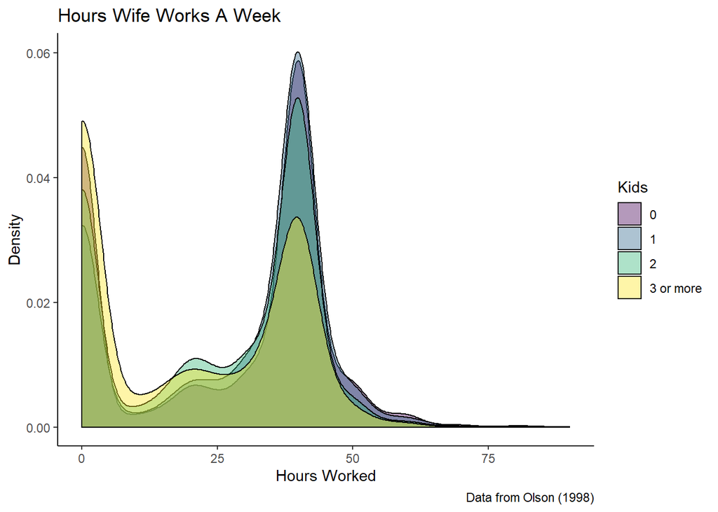

## Question 2: Sampling with my_cold_call()

### 2A)

```r
set.seed(10)
my_cold_call()
```

```
## [1] "Cassidy Bargell" "Emily Ni"        "Kelsey Wu"
```

### 2B)

Cold Calls

First Four Days of Class

| Day | Students |
| --- | --- |
| 1 | Yong Lee, Jenna Moustafa, Haeyun Lee, Belinda Hu |
| 2 | Rachel Phan, Garrett Rolph, Matej Cerman, Matej Cerman, Wyatt Hurt, John Morse, Emily Ni |
| 3 | Diassa Diakite, Chase Bookin |
| 4 | Henry Austin, Micah Williams, Rachel Auslander, Naina Tejani, Daniela Teran, Makenna Famulari, Cameron Reaves |

### 2C)

The percentage of days in which at least one of Eliot Min, Rachel Auslander, or Makenna Famulari had their name called is **11.11%**.